# Retour Blended 1

```r
# install if needed
if(!require("tidyverse")){install.packages("tidyverse")}
if(!require("rmarkdown")){install.packages("rmarkdown")}
if(!require(knitr)){install.packages(knitr)}

# load packages with no message or warning from chunk option
# alternative to suppressPackageStartupMessages(library("tidyverse"))
library("tidyverse")
library(rmarkdown)
library(knitr)
```

## Purpose

Prepare the Quizz 1 with a practical example.

The `iris` dataset example should illustrate :

- part of the work of a data scientist
- some tools used
  - viz
  - ML (lm, kmeans, cart, nnet, …)
- some ML methods used
  - train - test
  - CV
- some methodology in the study :
  - descriptive analysis
  - predictive analysis
  - prescriptive analysis

## Context

[extract from the help of the dataset `iris` description]

“This famous (Fisher’s or Anderson’s) iris data set gives the measurements in centimeters of the variables sepal length and width and petal length and width, respectively, for 50 flowers from each of 3 species of iris. The species are Iris setosa, versicolor, and virginica.”

```r
iris %>% head() %>%  knitr::kable()
```

| Sepal.Length | Sepal.Width | Petal.Length | Petal.Width | Species |
| --- | --- | --- | --- | --- |
| 5.1 | 3.5 | 1.4 | 0.2 | setosa |
| 4.9 | 3.0 | 1.4 | 0.2 | setosa |
| 4.7 | 3.2 | 1.3 | 0.2 | setosa |
| 4.6 | 3.1 | 1.5 | 0.2 | setosa |
| 5.0 | 3.6 | 1.4 | 0.2 | setosa |
| 5.4 | 3.9 | 1.7 | 0.4 | setosa |

```r
iris %>% dplyr::glimpse()
```

```
## Observations: 150
## Variables: 5
## $ Sepal.Length <dbl> 5.1, 4.9, 4.7, 4.6, 5.0, 5.4, 4.6, 5.0, 4.4, 4.9,...
## $ Sepal.Width  <dbl> 3.5, 3.0, 3.2, 3.1, 3.6, 3.9, 3.4, 3.4, 2.9, 3.1,...
## $ Petal.Length <dbl> 1.4, 1.4, 1.3, 1.5, 1.4, 1.7, 1.4, 1.5, 1.4, 1.5,...
## $ Petal.Width  <dbl> 0.2, 0.2, 0.2, 0.2, 0.2, 0.4, 0.3, 0.2, 0.2, 0.1,...
## $ Species      <fct> setosa, setosa, setosa, setosa, setosa, setosa, s...
```

## Problem formulation

Given measurment of petal and sepal’s flowers, predict in which species of iris a flower is. This type of problem is called supervised learning problem, this is moreover a classification task.

## Vizualisations

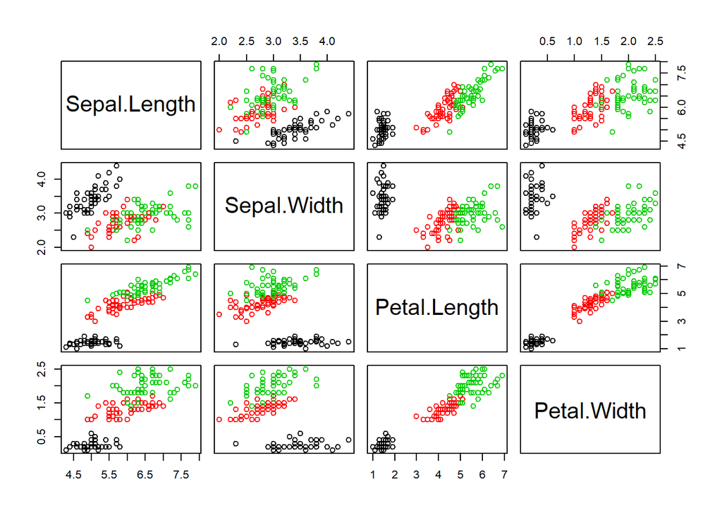

```r
# ?plot()
plot(iris[,-5], col = iris$Species)
```

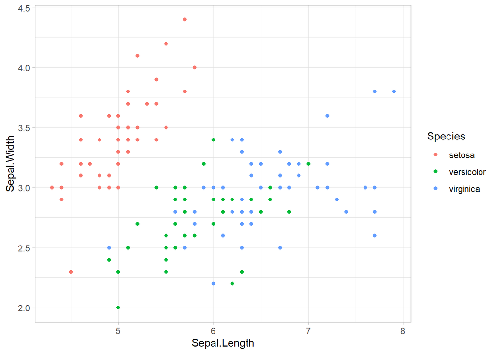

```r
# ggplot
iris %>%
  ggplot(aes(x = Sepal.Length, y = Sepal.Width, colour = Species)) +
  geom_point() +
  theme_light()
```

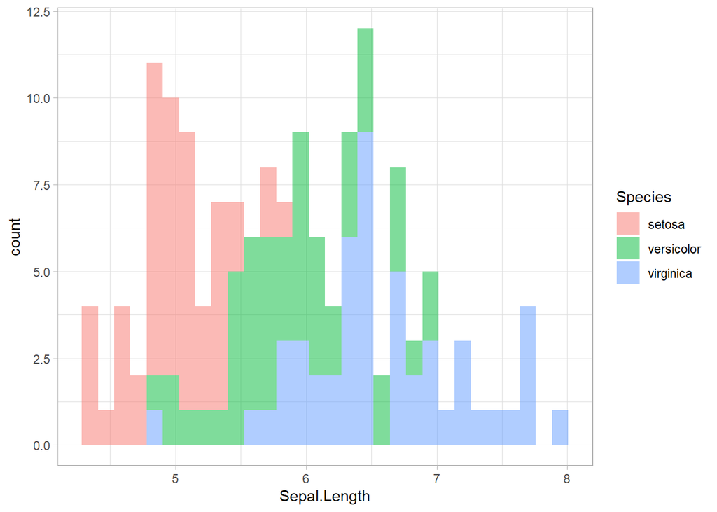

```r
iris %>%
  ggplot(aes(x = Sepal.Length, fill = Species)) +
  geom_histogram(alpha = .5) +
  theme_light()
```

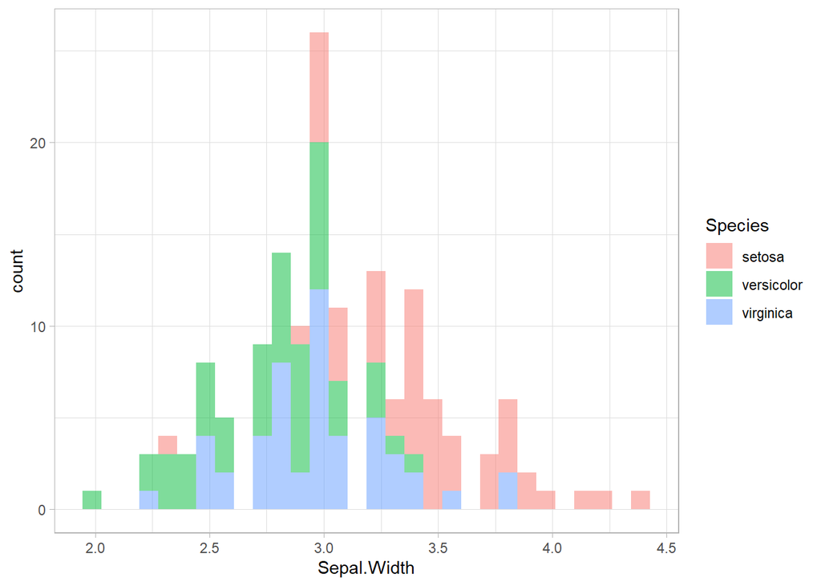

```r
iris %>%
  ggplot(aes(x = Sepal.Width, fill = Species)) +
  geom_histogram(alpha = .5) +
  theme_light()
```

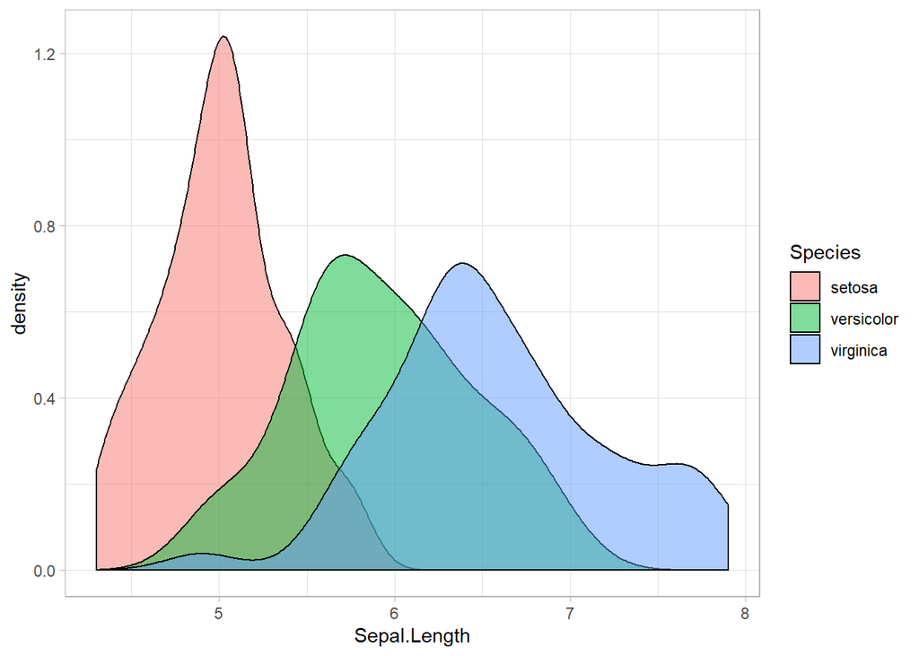

```r
iris %>%
  ggplot(aes(x = Sepal.Length, fill = Species)) +
  geom_density(alpha = .5) +
  theme_light()
```

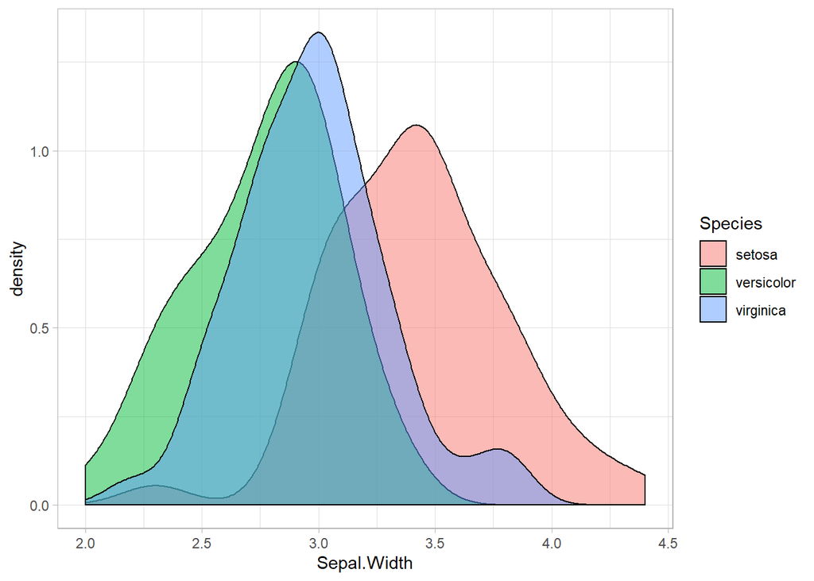

```r
iris %>%
  ggplot(aes(x = Sepal.Width, fill = Species)) +
  geom_density(alpha = .5) +
  theme_light()
```

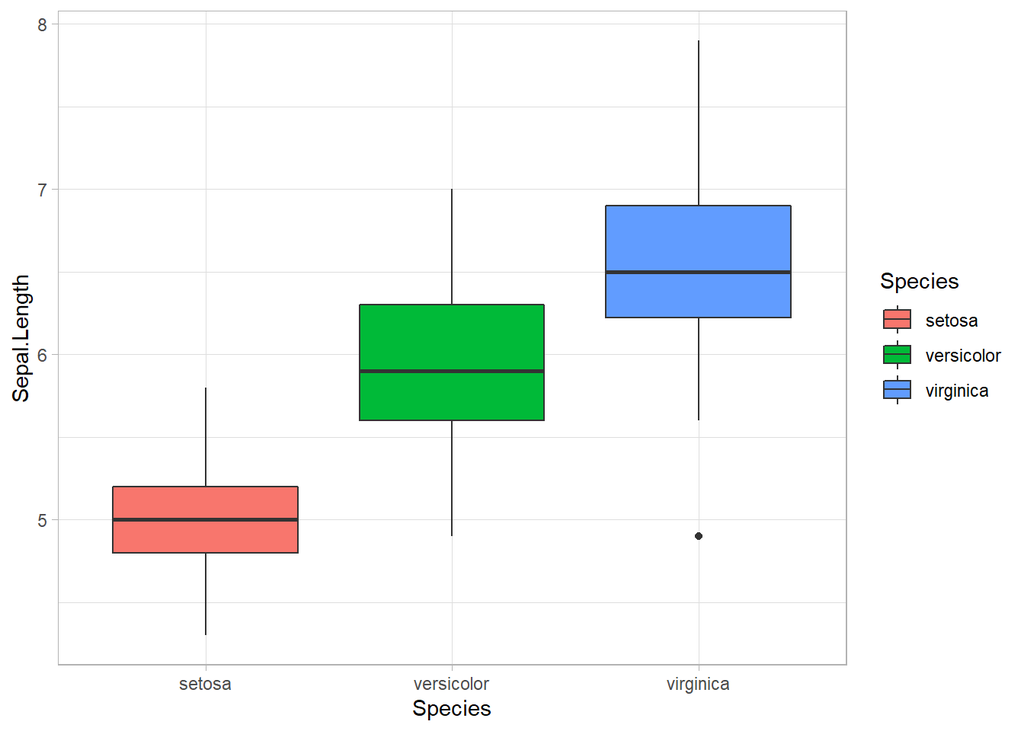

```r
iris %>%
  ggplot(aes(x =Species, y = Sepal.Length, fill = Species)) +
  geom_boxplot() +
  theme_light()
```

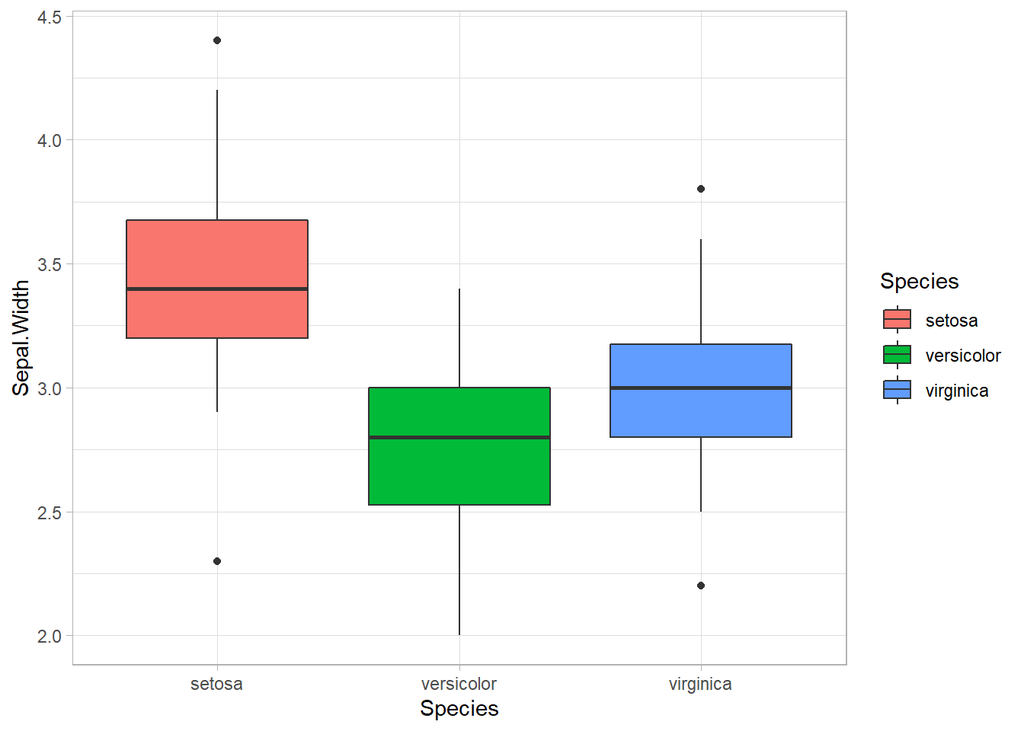

```r
iris %>%
  ggplot(aes(x= Species, y = Sepal.Width, fill = Species)) +
  geom_boxplot() +
  theme_light()
```